# Optimal Treatment Analysis

## Outcome Variable

**Outcome Variable:** whz

## Predictor Variables

**Intervention Variable:** fage

**Adjustment Set:**

- arm
- W_mage
- meducyrs
- feducyrs
- W_mhtcm
- W_mwtkg
- W_mbmi
- W_fhtcm
- single
- brthmon
- delta_W_mage
- delta_meducyrs
- delta_feducyrs
- delta_W_mhtcm
- delta_W_mwtkg
- delta_W_mbmi
- delta_W_fhtcm
- delta_single
- delta_brthmon

## Stratifying Variables

The analysis was stratified on these variable(s):

- agecat
- studyid
- country

## Data Summary

| agecat | studyid | country | fage | n_cell | n |
| --- | --- | --- | --- | --- | --- |
| Birth | ki0047075b-MAL-ED | BANGLADESH | >=38 | 61 | 128 |
| Birth | ki0047075b-MAL-ED | BANGLADESH | <32 | 23 | 128 |
| Birth | ki0047075b-MAL-ED | BANGLADESH | [32-38) | 44 | 128 |
| Birth | ki0047075b-MAL-ED | BRAZIL | >=38 | 5 | 16 |
| Birth | ki0047075b-MAL-ED | BRAZIL | <32 | 1 | 16 |
| Birth | ki0047075b-MAL-ED | BRAZIL | [32-38) | 10 | 16 |
| Birth | ki0047075b-MAL-ED | INDIA | >=38 | 7 | 25 |
| Birth | ki0047075b-MAL-ED | INDIA | <32 | 8 | 25 |
| Birth | ki0047075b-MAL-ED | INDIA | [32-38) | 10 | 25 |
| Birth | ki0047075b-MAL-ED | NEPAL | >=38 | 2 | 9 |
| Birth | ki0047075b-MAL-ED | NEPAL | <32 | 2 | 9 |
| Birth | ki0047075b-MAL-ED | NEPAL | [32-38) | 5 | 9 |
| Birth | ki0047075b-MAL-ED | PERU | >=38 | 23 | 67 |
| Birth | ki0047075b-MAL-ED | PERU | <32 | 21 | 67 |
| Birth | ki0047075b-MAL-ED | PERU | [32-38) | 23 | 67 |
| Birth | ki0047075b-MAL-ED | SOUTH AFRICA | >=38 | 16 | 30 |
| Birth | ki0047075b-MAL-ED | SOUTH AFRICA | <32 | 5 | 30 |
| Birth | ki0047075b-MAL-ED | SOUTH AFRICA | [32-38) | 9 | 30 |
| Birth | ki0047075b-MAL-ED | TANZANIA, UNITED REPUBLIC OF | >=38 | 17 | 44 |
| Birth | ki0047075b-MAL-ED | TANZANIA, UNITED REPUBLIC OF | <32 | 9 | 44 |
| Birth | ki0047075b-MAL-ED | TANZANIA, UNITED REPUBLIC OF | [32-38) | 18 | 44 |
| Birth | ki1000304b-SAS-CompFeed | INDIA | >=38 | 34 | 1101 |
| Birth | ki1000304b-SAS-CompFeed | INDIA | <32 | 923 | 1101 |
| Birth | ki1000304b-SAS-CompFeed | INDIA | [32-38) | 144 | 1101 |
| Birth | ki1119695-PROBIT | BELARUS | >=38 | 606 | 13339 |
| Birth | ki1119695-PROBIT | BELARUS | <32 | 10681 | 13339 |
| Birth | ki1119695-PROBIT | BELARUS | [32-38) | 2052 | 13339 |
| Birth | ki1135781-COHORTS | GUATEMALA | >=38 | 222 | 735 |
| Birth | ki1135781-COHORTS | GUATEMALA | <32 | 337 | 735 |
| Birth | ki1135781-COHORTS | GUATEMALA | [32-38) | 176 | 735 |

[output cut: 75 more lines]

The following strata were considered:

- agecat: 24 months, studyid: ki0047075b-MAL-ED, country: BANGLADESH
- agecat: 24 months, studyid: ki0047075b-MAL-ED, country: BRAZIL
- agecat: 24 months, studyid: ki0047075b-MAL-ED, country: INDIA
- agecat: 24 months, studyid: ki0047075b-MAL-ED, country: NEPAL
- agecat: 24 months, studyid: ki0047075b-MAL-ED, country: PERU
- agecat: 24 months, studyid: ki0047075b-MAL-ED, country: SOUTH AFRICA
- agecat: 24 months, studyid: ki0047075b-MAL-ED, country: TANZANIA, UNITED REPUBLIC OF
- agecat: 24 months, studyid: ki1119695-PROBIT, country: BELARUS
- agecat: 24 months, studyid: ki1135781-COHORTS, country: GUATEMALA
- agecat: 24 months, studyid: ki1135781-COHORTS, country: PHILIPPINES
- agecat: 24 months, studyid: ki1148112-LCNI-5, country: MALAWI
- agecat: 6 months, studyid: ki0047075b-MAL-ED, country: BANGLADESH
- agecat: 6 months, studyid: ki0047075b-MAL-ED, country: BRAZIL
- agecat: 6 months, studyid: ki0047075b-MAL-ED, country: INDIA
- agecat: 6 months, studyid: ki0047075b-MAL-ED, country: NEPAL
- agecat: 6 months, studyid: ki0047075b-MAL-ED, country: PERU
- agecat: 6 months, studyid: ki0047075b-MAL-ED, country: SOUTH AFRICA
- agecat: 6 months, studyid: ki0047075b-MAL-ED, country: TANZANIA, UNITED REPUBLIC OF
- agecat: 6 months, studyid: ki1000304b-SAS-CompFeed, country: INDIA
- agecat: 6 months, studyid: ki1000304b-SAS-FoodSuppl, country: INDIA
- agecat: 6 months, studyid: ki1119695-PROBIT, country: BELARUS
- agecat: 6 months, studyid: ki1135781-COHORTS, country: GUATEMALA
- agecat: 6 months, studyid: ki1135781-COHORTS, country: PHILIPPINES
- agecat: 6 months, studyid: ki1148112-LCNI-5, country: MALAWI
- agecat: Birth, studyid: ki0047075b-MAL-ED, country: BANGLADESH
- agecat: Birth, studyid: ki0047075b-MAL-ED, country: BRAZIL
- agecat: Birth, studyid: ki0047075b-MAL-ED, country: INDIA
- agecat: Birth, studyid: ki0047075b-MAL-ED, country: NEPAL
- agecat: Birth, studyid: ki0047075b-MAL-ED, country: PERU
- agecat: Birth, studyid: ki0047075b-MAL-ED, country: SOUTH AFRICA
- agecat: Birth, studyid: ki0047075b-MAL-ED, country: TANZANIA, UNITED REPUBLIC OF
- agecat: Birth, studyid: ki1000304b-SAS-CompFeed, country: INDIA
- agecat: Birth, studyid: ki1119695-PROBIT, country: BELARUS
- agecat: Birth, studyid: ki1135781-COHORTS, country: GUATEMALA
- agecat: Birth, studyid: ki1135781-COHORTS, country: PHILIPPINES

### Dropped Strata

Some strata were dropped due to rare outcomes:

- agecat: Birth, studyid: ki0047075b-MAL-ED, country: BRAZIL
- agecat: Birth, studyid: ki0047075b-MAL-ED, country: NEPAL

## Methods Detail

We’re interested in the causal parameters $E[Y_a]$ for all values of $a \in \mathcal{A}$. These parameters represent the mean outcome if, possibly contrary to fact, we intervened to set all units to have $A=a$. Under the randomization and positivity assumptions, these are identified by the statistical parameters $\psi_a=E_W[E_{Y|A,W}(Y|A=a,W)]$. In addition, we’re interested in the mean of $Y$, $E[Y]$ under no intervention (the observed mean). We will estimate these parameters by using SuperLearner to fit the relevant likelihood factors – $E_{Y|A,W}(Y|A=a,W)$ and $p(A=a|W)$, and then updating our likelihood fit using a joint TMLE.

For unadjusted analyses ($W=\{\}$), initial likelihoods were estimated using Lrnr_glm to estimate the simple $E(Y|A)$ and Lrnr_mean to estimate $p(A)$. For adjusted analyses, a small library containing Lrnr_glmnet, Lrnr_xgboost, and Lrnr_mean was used.

Having estimated these parameters, we will then use the delta method to estimate relative risks and attributable risks relative to a prespecified baseline level of $A$.

# Results Detail

## Results Plots

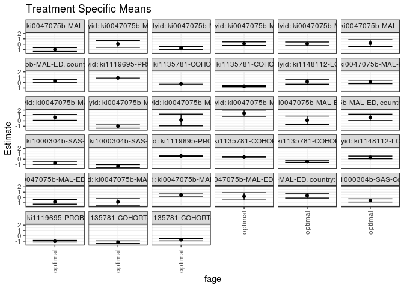

## Results Table

### Parameter: TSM

| agecat | studyid | country | intervention_level | baseline_level | estimate | ci_lower | ci_upper |
| --- | --- | --- | --- | --- | --- | --- | --- |
| Birth | ki0047075b-MAL-ED | BANGLADESH | optimal | observed | -0.8090645 | -1.2412661 | -0.3768629 |
| Birth | ki0047075b-MAL-ED | INDIA | optimal | observed | -0.8322380 | -1.4486317 | -0.2158442 |
| Birth | ki0047075b-MAL-ED | PERU | optimal | observed | 0.4642039 | 0.1116181 | 0.8167897 |
| Birth | ki0047075b-MAL-ED | SOUTH AFRICA | optimal | observed | 0.2163844 | -0.4600219 | 0.8927907 |
| Birth | ki0047075b-MAL-ED | TANZANIA, UNITED REPUBLIC OF | optimal | observed | 0.3396682 | -0.1068373 | 0.7861738 |
| Birth | ki1000304b-SAS-CompFeed | INDIA | optimal | observed | -0.5447912 | -0.8407381 | -0.2488443 |
| Birth | ki1119695-PROBIT | BELARUS | optimal | observed | -1.0082849 | -1.1679470 | -0.8486228 |
| Birth | ki1135781-COHORTS | GUATEMALA | optimal | observed | -1.1869186 | -1.4328831 | -0.9409540 |
| Birth | ki1135781-COHORTS | PHILIPPINES | optimal | observed | -0.7322830 | -0.9398245 | -0.5247415 |
| 6 months | ki0047075b-MAL-ED | BANGLADESH | optimal | observed | 0.1001990 | -0.2250598 | 0.4254578 |
| 6 months | ki0047075b-MAL-ED | BRAZIL | optimal | observed | 0.6473637 | 0.1019212 | 1.1928062 |
| 6 months | ki0047075b-MAL-ED | INDIA | optimal | observed | -0.9880900 | -1.3681588 | -0.6080212 |
| 6 months | ki0047075b-MAL-ED | NEPAL | optimal | observed | 0.1588671 | -0.9366528 | 1.2543871 |
| 6 months | ki0047075b-MAL-ED | PERU | optimal | observed | 1.4165142 | 0.8362389 | 1.9967896 |
| 6 months | ki0047075b-MAL-ED | SOUTH AFRICA | optimal | observed | 0.1064081 | -0.6661059 | 0.8789221 |
| 6 months | ki0047075b-MAL-ED | TANZANIA, UNITED REPUBLIC OF | optimal | observed | 0.6441792 | 0.0532736 | 1.2350848 |
| 6 months | ki1000304b-SAS-CompFeed | INDIA | optimal | observed | -0.7077075 | -0.9908767 | -0.4245383 |
| 6 months | ki1000304b-SAS-FoodSuppl | INDIA | optimal | observed | -1.2939618 | -1.5580377 | -1.0298859 |
| 6 months | ki1119695-PROBIT | BELARUS | optimal | observed | 0.5965327 | 0.5167265 | 0.6763390 |
| 6 months | ki1135781-COHORTS | GUATEMALA | optimal | observed | 0.3785607 | 0.2559130 | 0.5012085 |
| 6 months | ki1135781-COHORTS | PHILIPPINES | optimal | observed | -0.4467304 | -0.5941976 | -0.2992632 |
| 6 months | ki1148112-LCNI-5 | MALAWI | optimal | observed | 0.3278771 | 0.0795771 | 0.5761771 |
| 24 months | ki0047075b-MAL-ED | BANGLADESH | optimal | observed | -0.9842058 | -1.3353058 | -0.6331057 |
| 24 months | ki0047075b-MAL-ED | BRAZIL | optimal | observed | 0.0695512 | -0.5775023 | 0.7166047 |
| 24 months | ki0047075b-MAL-ED | INDIA | optimal | observed | -0.7321548 | -1.0199504 | -0.4443592 |
| 24 months | ki0047075b-MAL-ED | NEPAL | optimal | observed | 0.1077084 | -0.2245946 | 0.4400115 |
| 24 months | ki0047075b-MAL-ED | PERU | optimal | observed | 0.0810715 | -0.2533319 | 0.4154749 |
| 24 months | ki0047075b-MAL-ED | SOUTH AFRICA | optimal | observed | 0.2005508 | -0.4489113 | 0.8500128 |
| 24 months | ki0047075b-MAL-ED | TANZANIA, UNITED REPUBLIC OF | optimal | observed | 0.3206511 | 0.0461481 | 0.5951542 |
| 24 months | ki1119695-PROBIT | BELARUS | optimal | observed | 0.8641761 | 0.7400563 | 0.9882959 |
| 24 months | ki1135781-COHORTS | GUATEMALA | optimal | observed | -0.2476107 | -0.3758188 | -0.1194026 |
| 24 months | ki1135781-COHORTS | PHILIPPINES | optimal | observed | -0.6869813 | -0.7974150 | -0.5765475 |
| 24 months | ki1148112-LCNI-5 | MALAWI | optimal | observed | 0.1501589 | -0.3091898 | 0.6095075 |

### Parameter: E(Y)

| agecat | studyid | country | intervention_level | baseline_level | estimate | ci_lower | ci_upper |
| --- | --- | --- | --- | --- | --- | --- | --- |
| Birth | ki0047075b-MAL-ED | BANGLADESH | observed | observed | -1.0375000 | -1.2165024 | -0.8584976 |
| Birth | ki0047075b-MAL-ED | INDIA | observed | observed | -0.9464000 | -1.3554144 | -0.5373856 |
| Birth | ki0047075b-MAL-ED | PERU | observed | observed | 0.0529851 | -0.1628445 | 0.2688147 |
| Birth | ki0047075b-MAL-ED | SOUTH AFRICA | observed | observed | -0.0073333 | -0.5181900 | 0.5035233 |
| Birth | ki0047075b-MAL-ED | TANZANIA, UNITED REPUBLIC OF | observed | observed | 0.7115909 | 0.4034609 | 1.0197209 |
| Birth | ki1000304b-SAS-CompFeed | INDIA | observed | observed | -0.6685468 | -0.8459689 | -0.4911247 |
| Birth | ki1119695-PROBIT | BELARUS | observed | observed | -1.1395817 | -1.3497976 | -0.9293658 |
| Birth | ki1135781-COHORTS | GUATEMALA | observed | observed | -1.0580408 | -1.1607065 | -0.9553751 |
| Birth | ki1135781-COHORTS | PHILIPPINES | observed | observed | -0.7309760 | -0.7780724 | -0.6838797 |
| 6 months | ki0047075b-MAL-ED | BANGLADESH | observed | observed | -0.1950111 | -0.3575506 | -0.0324716 |
| 6 months | ki0047075b-MAL-ED | BRAZIL | observed | observed | 0.9365401 | 0.6541549 | 1.2189253 |
| 6 months | ki0047075b-MAL-ED | INDIA | observed | observed | -0.7292288 | -0.8803893 | -0.5780683 |
| 6 months | ki0047075b-MAL-ED | NEPAL | observed | observed | 0.1749789 | -0.0644624 | 0.4144202 |
| 6 months | ki0047075b-MAL-ED | PERU | observed | observed | 1.0182129 | 0.7827641 | 1.2536616 |
| 6 months | ki0047075b-MAL-ED | SOUTH AFRICA | observed | observed | 0.5158052 | 0.2517895 | 0.7798210 |
| 6 months | ki0047075b-MAL-ED | TANZANIA, UNITED REPUBLIC OF | observed | observed | 0.5271500 | 0.3177522 | 0.7365478 |
| 6 months | ki1000304b-SAS-CompFeed | INDIA | observed | observed | -0.6641059 | -0.8040033 | -0.5242086 |
| 6 months | ki1000304b-SAS-FoodSuppl | INDIA | observed | observed | -1.0121579 | -1.1280429 | -0.8962729 |
| 6 months | ki1119695-PROBIT | BELARUS | observed | observed | 0.5785982 | 0.5189015 | 0.6382948 |
| 6 months | ki1135781-COHORTS | GUATEMALA | observed | observed | 0.1925914 | 0.1205037 | 0.2646791 |
| 6 months | ki1135781-COHORTS | PHILIPPINES | observed | observed | -0.2878032 | -0.3296319 | -0.2459745 |
| 6 months | ki1148112-LCNI-5 | MALAWI | observed | observed | 0.5060377 | 0.3131397 | 0.6989358 |
| 24 months | ki0047075b-MAL-ED | BANGLADESH | observed | observed | -0.8844702 | -1.0263143 | -0.7426261 |
| 24 months | ki0047075b-MAL-ED | BRAZIL | observed | observed | 0.5448101 | 0.2082313 | 0.8813890 |
| 24 months | ki0047075b-MAL-ED | INDIA | observed | observed | -0.8968012 | -1.0287307 | -0.7648718 |
| 24 months | ki0047075b-MAL-ED | NEPAL | observed | observed | -0.2794304 | -0.4767398 | -0.0821210 |
| 24 months | ki0047075b-MAL-ED | PERU | observed | observed | 0.1198207 | -0.0845120 | 0.3241534 |
| 24 months | ki0047075b-MAL-ED | SOUTH AFRICA | observed | observed | 0.4414045 | 0.2336389 | 0.6491701 |
| 24 months | ki0047075b-MAL-ED | TANZANIA, UNITED REPUBLIC OF | observed | observed | 0.0766500 | -0.1115307 | 0.2648307 |
| 24 months | ki1119695-PROBIT | BELARUS | observed | observed | 0.6857534 | 0.5745271 | 0.7969798 |
| 24 months | ki1135781-COHORTS | GUATEMALA | observed | observed | -0.2760853 | -0.3311930 | -0.2209775 |
| 24 months | ki1135781-COHORTS | PHILIPPINES | observed | observed | -0.6087584 | -0.6459824 | -0.5715345 |
| 24 months | ki1148112-LCNI-5 | MALAWI | observed | observed | -0.1979730 | -0.4244675 | 0.0285215 |

### Parameter: PAR

| agecat | studyid | country | intervention_level | baseline_level | estimate | ci_lower | ci_upper |
| --- | --- | --- | --- | --- | --- | --- | --- |
| Birth | ki0047075b-MAL-ED | BANGLADESH | optimal | observed | -0.2284355 | -0.5996254 | 0.1427544 |
| Birth | ki0047075b-MAL-ED | INDIA | optimal | observed | -0.1141620 | -0.7386126 | 0.5102885 |
| Birth | ki0047075b-MAL-ED | PERU | optimal | observed | -0.4112189 | -0.7428746 | -0.0795631 |
| Birth | ki0047075b-MAL-ED | SOUTH AFRICA | optimal | observed | -0.2237177 | -0.7271809 | 0.2797454 |
| Birth | ki0047075b-MAL-ED | TANZANIA, UNITED REPUBLIC OF | optimal | observed | 0.3719227 | -0.0114129 | 0.7552583 |
| Birth | ki1000304b-SAS-CompFeed | INDIA | optimal | observed | -0.1237556 | -0.3654605 | 0.1179493 |
| Birth | ki1119695-PROBIT | BELARUS | optimal | observed | -0.1312968 | -0.2380366 | -0.0245569 |
| Birth | ki1135781-COHORTS | GUATEMALA | optimal | observed | 0.1288777 | -0.0996076 | 0.3573631 |
| Birth | ki1135781-COHORTS | PHILIPPINES | optimal | observed | 0.0013070 | -0.2021144 | 0.2047283 |
| 6 months | ki0047075b-MAL-ED | BANGLADESH | optimal | observed | -0.2952101 | -0.5992391 | 0.0088189 |
| 6 months | ki0047075b-MAL-ED | BRAZIL | optimal | observed | 0.2891764 | -0.1527520 | 0.7311048 |
| 6 months | ki0047075b-MAL-ED | INDIA | optimal | observed | 0.2588612 | -0.0747773 | 0.5924998 |
| 6 months | ki0047075b-MAL-ED | NEPAL | optimal | observed | 0.0161118 | -0.9823172 | 1.0145407 |
| 6 months | ki0047075b-MAL-ED | PERU | optimal | observed | -0.3983014 | -0.8480024 | 0.0513996 |
| 6 months | ki0047075b-MAL-ED | SOUTH AFRICA | optimal | observed | 0.4093971 | -0.2902388 | 1.1090331 |
| 6 months | ki0047075b-MAL-ED | TANZANIA, UNITED REPUBLIC OF | optimal | observed | -0.1170292 | -0.6459472 | 0.4118888 |
| 6 months | ki1000304b-SAS-CompFeed | INDIA | optimal | observed | 0.0436016 | -0.1504717 | 0.2376749 |
| 6 months | ki1000304b-SAS-FoodSuppl | INDIA | optimal | observed | 0.2818039 | 0.0328628 | 0.5307450 |
| 6 months | ki1119695-PROBIT | BELARUS | optimal | observed | -0.0179346 | -0.0833358 | 0.0474667 |
| 6 months | ki1135781-COHORTS | GUATEMALA | optimal | observed | -0.1859694 | -0.2983648 | -0.0735739 |
| 6 months | ki1135781-COHORTS | PHILIPPINES | optimal | observed | 0.1589272 | 0.0149309 | 0.3029234 |
| 6 months | ki1148112-LCNI-5 | MALAWI | optimal | observed | 0.1781607 | -0.0660448 | 0.4223661 |
| 24 months | ki0047075b-MAL-ED | BANGLADESH | optimal | observed | 0.0997356 | -0.2082993 | 0.4077705 |
| 24 months | ki0047075b-MAL-ED | BRAZIL | optimal | observed | 0.4752590 | -0.1311474 | 1.0816653 |
| 24 months | ki0047075b-MAL-ED | INDIA | optimal | observed | -0.1646464 | -0.4390912 | 0.1097983 |
| 24 months | ki0047075b-MAL-ED | NEPAL | optimal | observed | -0.3871388 | -0.7017630 | -0.0725146 |
| 24 months | ki0047075b-MAL-ED | PERU | optimal | observed | 0.0387492 | -0.2536184 | 0.3311169 |
| 24 months | ki0047075b-MAL-ED | SOUTH AFRICA | optimal | observed | 0.2408537 | -0.3698869 | 0.8515944 |
| 24 months | ki0047075b-MAL-ED | TANZANIA, UNITED REPUBLIC OF | optimal | observed | -0.2440011 | -0.4479824 | -0.0400198 |
| 24 months | ki1119695-PROBIT | BELARUS | optimal | observed | -0.1784227 | -0.3071411 | -0.0497042 |
| 24 months | ki1135781-COHORTS | GUATEMALA | optimal | observed | -0.0284745 | -0.1445303 | 0.0875813 |
| 24 months | ki1135781-COHORTS | PHILIPPINES | optimal | observed | 0.0782228 | -0.0264457 | 0.1828914 |
| 24 months | ki1148112-LCNI-5 | MALAWI | optimal | observed | -0.3481318 | -0.7323292 | 0.0360655 |